# **Importing Necessary Libraries**

#### (II) Category-wise Trend

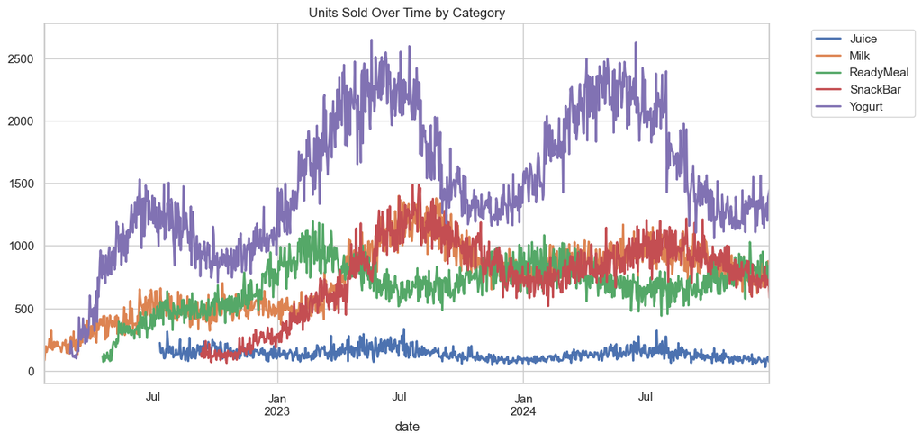

```python
# Time trends by category
df_cat_trend = df.groupby(["date", "category"])["units_sold"].sum().unstack()
df_cat_trend.plot(title="Units Sold Over Time by Category", lw=2)
plt.legend(bbox_to_anchor=(1.05, 1), loc="upper left")
plt.show()
```

# **Objective 2: Price Impact on Sales**

### Correlation Analysis (Pearson)

```python
correlation = df['price_unit'].corr(df['units_sold'])
print("Correlation between Price and Sales:", correlation)
```

```
Correlation between Price and Sales: -0.0010850357751209553
```

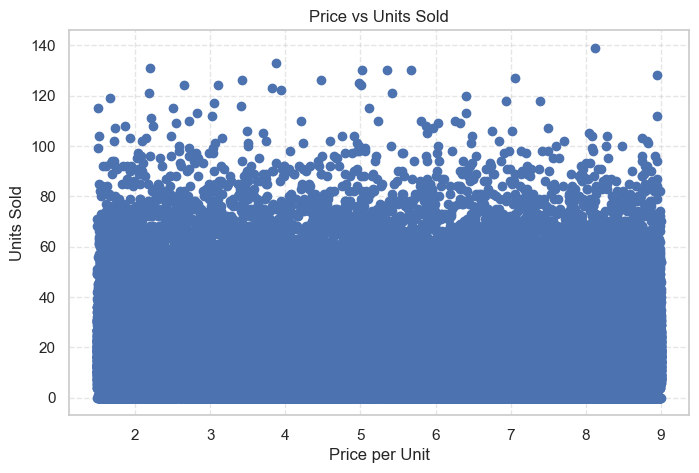

```python
plt.figure(figsize=(8,5))
plt.scatter(df['price_unit'], df['units_sold'])
plt.title('Price vs Units Sold')
plt.xlabel('Price per Unit')
plt.ylabel('Units Sold')
plt.grid(True, linestyle='--', alpha=0.5)
plt.show()
```

## **Spearman’s Rank Correlation Coefficient Test**

### **Assumptions of Spearman’s Rank Correlation Coefficient Test**

1. Variables are at least Ordinal
- The variables should be ordinal, interval, or ratio.
- Data must be capable of being ranked.

✅ This assumption is satisfied.

2. Monotonic Relationship
- The relationship between the two variables should be monotonic:
  - As one variable increases, the other consistently increases or decreases.
- The relationship does not have to be linear.

❌ This assumption is not satisfied.

3. Paired Observations
- Each observation in one variable must have a corresponding observation in the other variable.
- Data should be measured on the same set of cases.

✅ This assumption is satisfied.

4. Independence of Observations
- Each pair of observations must be independent of all other pairs.
- No repeated or related measurements.

✅ This assumption is satisfied.

5. No Requirement of Normality
- Spearman’s method does NOT assume normal distribution of variables.
- This makes it suitable for skewed data.

✅ This assumption is satisfied.

6. Robust to Outliers
- The method is less sensitive to outliers because it uses ranks instead of raw values.
- Extreme values should not dominate the relationship.

✅ This assumption is satisfied.

**Conclusion:**

- Here our all assumptions satisfied except Assumption no. 2 which is Monotonic Relationship but still we could use Spearman’s Rank Correlation Coefficient Test because it does not affect the result that much.

```python
# Spearman correlation
corr, p_value = spearmanr(df['price_unit'], df['units_sold'])

print("Spearman Correlation Coefficient:", corr)
print("P-value:", p_value)
```

```
Spearman Correlation Coefficient: -0.0008915315272088063
P-value: 0.6969969664572935
```

## **Kruskal-Wallis Test**

### **Assumption of Kruskal-Wallis Test**

1. Independent Samples
- The groups being compared must be independent of each other.
- No observation should belong to more than one group.

✅ This assumption is satisfied.

2. Ordinal or Continuous Dependent Variable
- The dependent variable should be ordinal, interval, or ratio.
- Data must be suitable for ranking.

✅ This assumption is satisfied.

3. Categorical Independent Variable
- The independent variable must be categorical with two or more groups.
- Groups can be of unequal size.

✅ This assumption is satisfied.

4. Similar Distribution Shapes
- The distributions of the dependent variable across groups should have a similar shape.
- If shapes differ greatly, the test may reflect distribution differences rather than medians.

✅ This assumption is satisfied.

5. Random Sampling
- Observations should be randomly sampled from the population.

✅ This assumption is satisfied.

6. No Normality Assumption
- The Kruskal–Wallis test does NOT require normal distribution.
- Suitable for skewed data and outliers.

✅ This assumption is satisfied.

**Conclusion:**

- Here our all observation are satisfied so we could use Kruskal-Wallis Test.

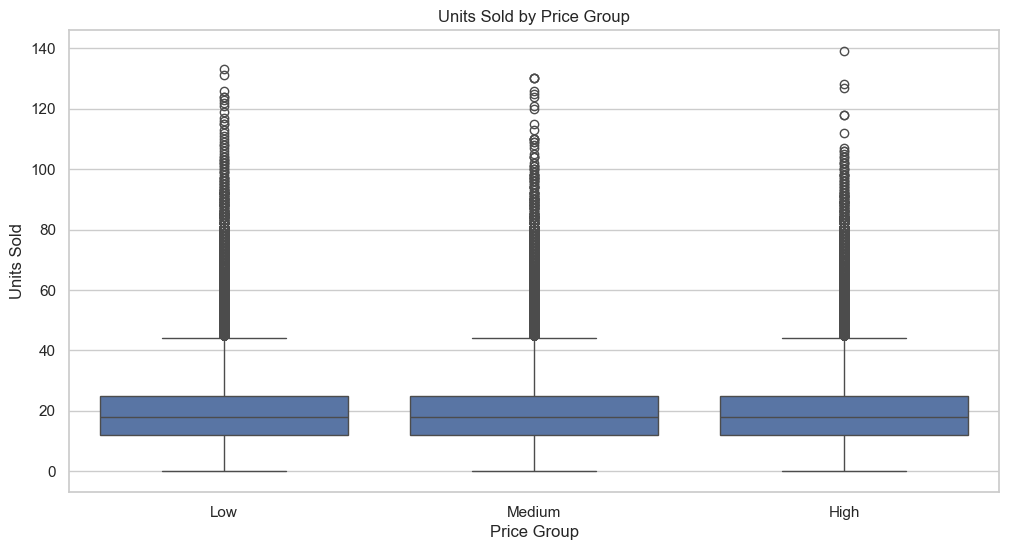

```python
sns.boxplot(x='price_range', y='units_sold', data=df)
plt.title("Units Sold by Price Group")
plt.xlabel("Price Group")
plt.ylabel("Units Sold")
plt.show()
```

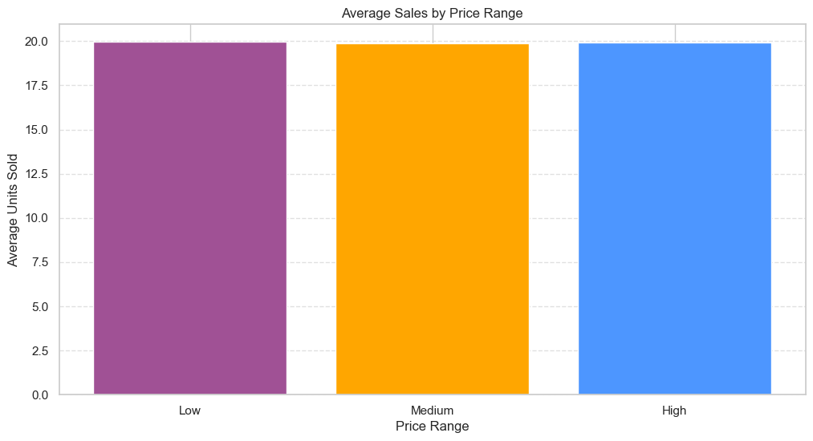

```python
plt.figure()
plt.bar(price_sales.index, price_sales.values, color = ['#a05195','#ffa600','#4D96FF'])
plt.title('Average Sales by Price Range')
plt.xlabel('Price Range')
plt.ylabel('Average Units Sold')
plt.grid(axis='y', linestyle='--', alpha=0.6)
plt.show()
```

```python
stat, p_value = kruskal(Low, Medium, High)

print("Kruskal-Wallis chi-squared statistic: ", stat)
print("P-Value: ", p_value)
```

```
Kruskal-Wallis chi-squared statistic:  0.34793343688229883
P-Value:  0.8403248645144705
```

# **Objective 3: Effect of Promotion on Sales**

### 1. Descriptive Comparison of Promoted vs Non-Promoted Products

```python
comparison = (
    df.groupby('promotion_flag')
      .agg(avg_units_sold=('units_sold', 'mean'),
           avg_revenue=('Revenue', 'mean'))
      .round(2)
)

print(comparison)
```

```
                avg_units_sold  avg_revenue
promotion_flag
0                        17.44        91.50
1                        34.06       179.26
```

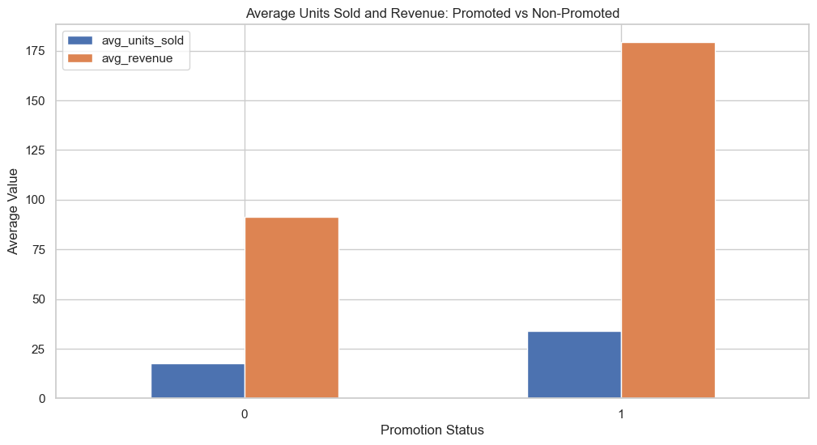

```python
import matplotlib.pyplot as plt

comparison.plot(kind='bar')
plt.title('Average Units Sold and Revenue: Promoted vs Non-Promoted')
plt.xlabel('Promotion Status')
plt.ylabel('Average Value')
plt.xticks(rotation=0)
plt.show()
```

### 2. Distribution Comparison Using Boxplots

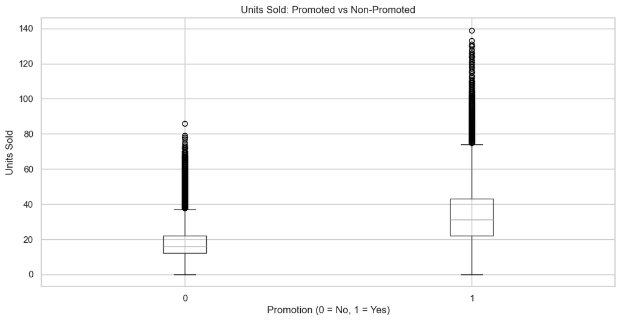

```python
import matplotlib.pyplot as plt

plt.figure()
df.boxplot(column='units_sold', by='promotion_flag')
plt.title('Units Sold: Promoted vs Non-Promoted')
plt.suptitle('')
plt.xlabel('Promotion (0 = No, 1 = Yes)')
plt.ylabel('Units Sold')
plt.show()
```

### 3. Mann–Whitney U Test

```python
from scipy.stats import mannwhitneyu

# Separate groups
promoted = df[df['promotion_flag'] == 1]['units_sold']
non_promoted = df[df['promotion_flag'] == 0]['units_sold']

# Test for units_sold
stat, p = mannwhitneyu(promoted, non_promoted)

print("Mann-Whitney U Test (Units Sold)")
print("Statistic:", stat)
print("p-value:", p)
```

```
Mann-Whitney U Test (Units Sold)
Statistic: 3834404037.5
p-value: 0.0
```

### 4. Promotion Impact Across Region

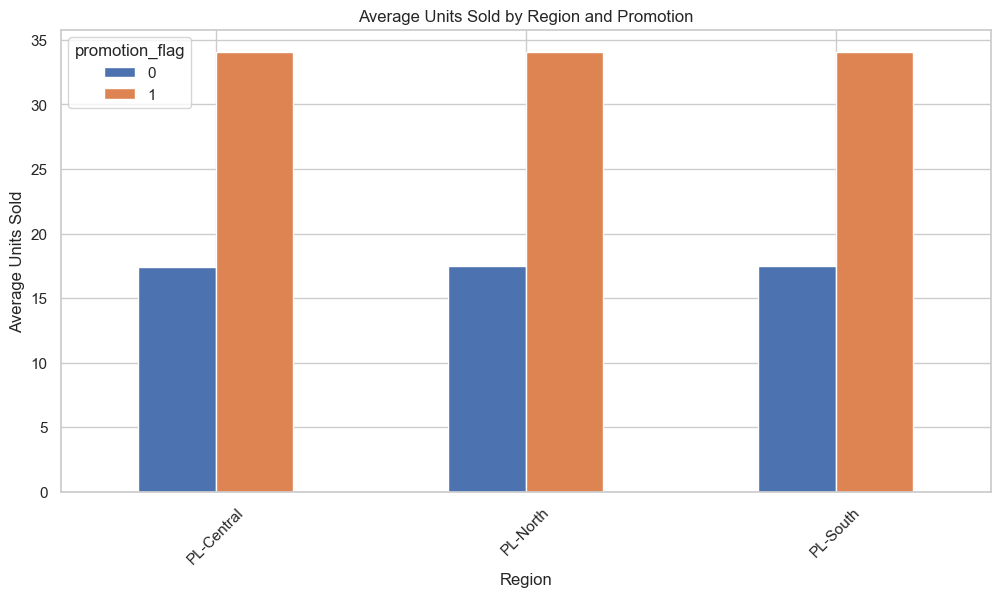

```python
region_promo = (
    df.groupby(['region', 'promotion_flag'])['units_sold']
      .mean()
      .unstack()
)

region_promo.plot(kind='bar')
plt.title('Average Units Sold by Region and Promotion')
plt.xlabel('Region')
plt.ylabel('Average Units Sold')
plt.xticks(rotation=45)
plt.show()
```

### 5. Promotion Impact Across Channel

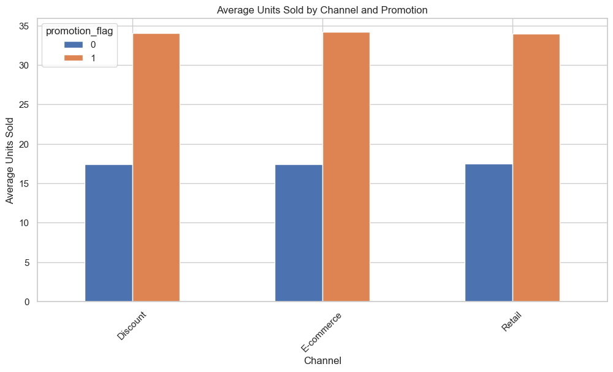

```python
channel_promo = (
    df.groupby(['channel', 'promotion_flag'])['units_sold']
      .mean()
      .unstack()
)

channel_promo.plot(kind='bar')
plt.title('Average Units Sold by Channel and Promotion')
plt.xlabel('Channel')
plt.ylabel('Average Units Sold')
plt.xticks(rotation=45)
plt.show()
```

# **Objective 4: Channel Performance Comparison**

### 1. Channel-wise Descriptive Statistics

```python
channel_stats = (
    df.groupby('channel')
      .agg(
          mean_units_sold=('units_sold', 'mean'),
          median_units_sold=('units_sold', 'median'),
          mean_revenue=('Revenue', 'mean'),
          median_revenue=('Revenue', 'median')
      )
      .round(2)
)

print(channel_stats)
```

```
            mean_units_sold  median_units_sold  mean_revenue  median_revenue
channel
Discount              19.92               18.0        104.69           85.50
E-commerce            19.94               18.0        104.58           85.40
Retail                19.90               18.0        104.51           85.41
```

### 2. Average Units Sold Across Channels

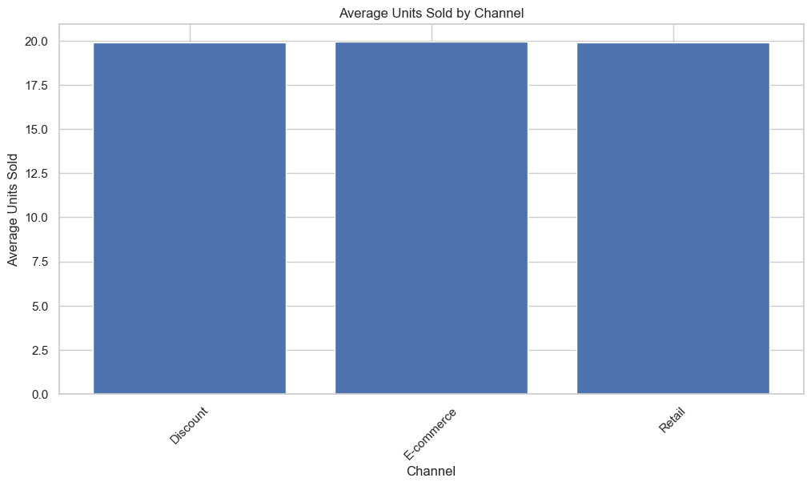

```python
import matplotlib.pyplot as plt

# Calculate average units_sold by channel
avg_sales = df.groupby('channel')['units_sold'].mean()

plt.figure()
plt.bar(avg_sales.index, avg_sales.values)
plt.title('Average Units Sold by Channel')
plt.xlabel('Channel')
plt.ylabel('Average Units Sold')
plt.xticks(rotation=45)
plt.show()
```

### 3. Distribution of Units Sold Across Channels

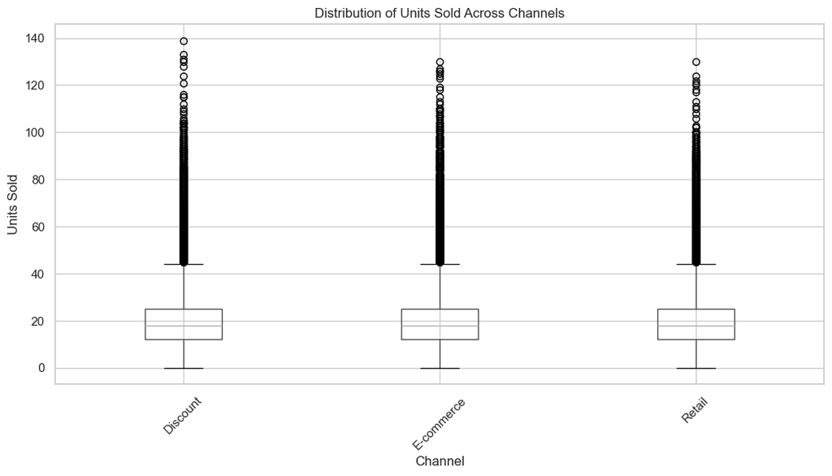

```python
plt.figure()
df.boxplot(column='units_sold', by='channel')
plt.title('Distribution of Units Sold Across Channels')
plt.suptitle('')
plt.xlabel('Channel')
plt.ylabel('Units Sold')
plt.xticks(rotation=45)
plt.show()
```

### 4. Units sold Comparison

```python
 # Group units_sold by channel
channel_groups_units = [
    group['units_sold'].values
    for name, group in df.groupby('channel')
]

# Perform test
h_stat_units, p_value_units = kruskal(*channel_groups_units)

print("Kruskal–Wallis Test (Units Sold Across Channels)")
print("H-statistic:", h_stat_units)
print("p-value:", p_value_units)
```

```
Kruskal–Wallis Test (Units Sold Across Channels)
H-statistic: 0.12428629037911208
p-value: 0.9397483567059958
```

#### Interpretation (Based on 5% Significance Level)

```python
alpha = 0.05

if p_value_units < alpha:
    print("\nReject H₀: At least one channel differs significantly in Units Sold.")
else:
    print("\nFail to Reject H₀: No significant difference in Units Sold across channels.")
```

```
Fail to Reject H₀: No significant difference in Units Sold across channels.
```

### 5. Effect Size Analysis

```python
import numpy as np

# overall mean
overall_mean = df['units_sold'].mean()

# between group sum of squares
ss_between = sum(
    len(group) * (group['units_sold'].mean() - overall_mean)**2
    for name, group in df.groupby('channel')
)

# total sum of squares
ss_total = sum((df['units_sold'] - overall_mean)**2)

eta_squared = ss_between / ss_total

print("Effect Size (Eta Squared):", eta_squared)
```

```
Effect Size (Eta Squared): 2.292031341291884e-06
```

### 6. Revenue Comparison

```python
channel_groups_rev = [
    group['Revenue'].values
    for name, group in df.groupby('channel')
]

h_stat_rev, p_value_rev = kruskal(*channel_groups_rev)

print("Kruskal–Wallis Test (Revenue)")
print("H-statistic:", h_stat_rev)
print("p-value:", p_value_rev)
```

```
Kruskal–Wallis Test (Revenue)
H-statistic: 0.3701838173882062
p-value: 0.8310279016528812
```

#### Interpretation (Based on 5% Significance Level)

```python
alpha = 0.05

if p_value_rev < alpha:
    print("Reject H₀: At least one channel differs significantly in Revenue.")
else:
    print("Fail to Reject H₀: No significant difference in Revenue across channels.")
```

```
Fail to Reject H₀: No significant difference in Revenue across channels.
```

### 7. Consistency Analysis (CV)

```python
cv = df.groupby('channel')['units_sold'].std() / df.groupby('channel')['units_sold'].mean()

print("Coefficient of Variation:")
print(cv)
```

```
Coefficient of Variation:
channel
Discount      0.590821
E-commerce    0.592797
Retail        0.588861
Name: units_sold, dtype: float64
```

# **Objective 5: Inventory & Stock Efficiency**

### 1. Descriptive Analysis

```python
# Summary statistics
stock_sales_summary = df[['stock_available', 'units_sold']].describe()
print(stock_sales_summary)
```

```
       stock_available     units_sold
count    190754.000000  190754.000000
mean        157.700237      19.920211
std          52.732487      11.769429
min           0.000000       0.000000
25%         124.000000      12.000000
50%         155.000000      18.000000
75%         192.000000      25.000000
max         405.000000     139.000000
```

### 2. Inventory Efficiency Metrics

#### (I) Stock-to-Sales Ratio

```python
# Average ratio
avg_stock_sales_ratio = df['stock_to_sales_ratio'].mean()

print("Average Stock-to-Sales Ratio:", round(avg_stock_sales_ratio, 2))
```

```
Average Stock-to-Sales Ratio: 9.18
```

#### Interpretation:

The average stock-to-sales ratio of 9.18 indicates that inventory levels are significantly higher than sales volume, suggesting potential overstocking and inefficient inventory management.

#### (II) Inventory Turnover Ratio

```python
# Average turnover
avg_turnover = df['inventory_turnover'].mean()

print("Average Inventory Turnover Ratio:", round(avg_turnover, 2))
```

```
Average Inventory Turnover Ratio: 0.12
```

#### Interpretation:

The average inventory turnover ratio of 0.12 indicates slow stock movement, suggesting excess inventory and possible inefficiencies in demand forecasting and inventory planning.

### 3. Visual Analysis

#### Scatter Plot (Stock vs Sales)

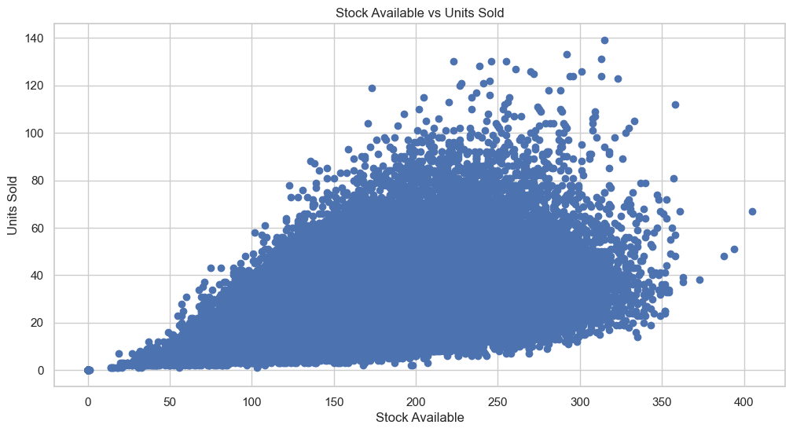

```python
plt.figure()
plt.scatter(df['stock_available'], df['units_sold'])
plt.title('Stock Available vs Units Sold')
plt.xlabel('Stock Available')
plt.ylabel('Units Sold')
plt.show()
```

### 4. Correlation Analysis

#### Spearman Correlation

```python
spearman_corr, spearman_p = stats.spearmanr(df['stock_available'], df['units_sold'])

print("\nSpearman Correlation")
print("Correlation Coefficient:", round(spearman_corr, 3))
print("p-value:", spearman_p)
```

```
Spearman Correlation
Correlation Coefficient: 0.638
p-value: 0.0
```